# Intro to Programming Nanodegree

Student: George J. J. Wu

Date: June 22, 2017

# Investigate a Dataset: Survival on the Titanic

[Kaggle](https://www.kaggle.com/c/titanic) provides an excellent overview on the sinking of the RMS Titanic:

> The sinking of the RMS Titanic is one of the most infamous shipwrecks in history. On April 15, 1912, during her maiden voyage, the Titanic sank after colliding with an iceberg, killing 1502 out of 2224 passengers and crew. This sensational tragedy shocked the international community and led to better safety regulations for ships.

> One of the reasons that the shipwreck led to such loss of life was that there were not enough lifeboats for the passengers and crew. Although there was some element of luck involved in surviving the sinking, some groups of people were more likely to survive than others, such as women, children, and the upper-class.

# Questions for Analysis

The current investigation seeks to identify key factors that are associated with the survival of the Titanic passengers. Specifically, the current investigation aims to explore the following questions:

1. What is the relationship between passengers' sex and their survival?
2. What is the relationship between passengers' age and their survival?
3. What is the relationship between passengers' socio-economic status and their survival?
4. What are the interactions among passengers' sex, age, and socio-economic status, with regard to the passengers' survival?

# Dataset

The *titanic_data* file contains demographics and travel information from 891 of the 2224 passengers and crew on board the Titanic. A full description of the dataset can be found on [Kaggle](https://www.kaggle.com/c/titanic/data).

```python
# data wrangling and analysis libraries
import numpy as np
import pandas as pd

# data visualization libraries
import matplotlib.pyplot as plt
import seaborn as sns
import plotly.plotly as py
import plotly.graph_objs as go
py.sign_in("georgejjwu", "WgRTlBfEZT7NzuWh2gCH")

# set style to default
%matplotlib inline
sns.set()
```

```python
# Load data file to Dataframe
df = pd.read_csv("titanic_data.csv")
```

```python
# preview dataset
df.head()
```

|  | PassengerId | Survived | Pclass | Name | Sex | Age | SibSp | Parch | Ticket | Fare | Cabin | Embarked |
| --- | --- | --- | --- | --- | --- | --- | --- | --- | --- | --- | --- | --- |
| 0 | 1 | 0 | 3 | Braund, Mr. Owen Harris | male | 22.0 | 1 | 0 | A/5 21171 | 7.2500 | NaN | S |
| 1 | 2 | 1 | 1 | Cumings, Mrs. John Bradley (Florence Briggs Th... | female | 38.0 | 1 | 0 | PC 17599 | 71.2833 | C85 | C |
| 2 | 3 | 1 | 3 | Heikkinen, Miss. Laina | female | 26.0 | 0 | 0 | STON/O2. 3101282 | 7.9250 | NaN | S |
| 3 | 4 | 1 | 1 | Futrelle, Mrs. Jacques Heath (Lily May Peel) | female | 35.0 | 1 | 0 | 113803 | 53.1000 | C123 | S |
| 4 | 5 | 0 | 3 | Allen, Mr. William Henry | male | 35.0 | 0 | 0 | 373450 | 8.0500 | NaN | S |

# Data Wrangling

## Missing values

```python
# identify missing values
df.count()
```

```
PassengerId    891
Survived       891
Pclass         891
Name           891
Sex            891
Age            714
SibSp          891
Parch          891
Ticket         891
Fare           891
Cabin          204
Embarked       889
dtype: int64
```

For the current sample of 891 passengers, initial analysis suggests that 2 entries are missing from the column *Embarked*, 177 entries are missing from the column *Age*, and 687 entries are missing from the column *Cabin*.

## Missing embarkment

```python
# identify passengers with missing embarkment information
df[(df["Embarked"] != 'S') & (df["Embarked"] != 'C') & (df["Embarked"] != 'Q')]
```

|  | PassengerId | Survived | Pclass | Name | Sex | Age | SibSp | Parch | Ticket | Fare | Cabin | Embarked |
| --- | --- | --- | --- | --- | --- | --- | --- | --- | --- | --- | --- | --- |
| 61 | 62 | 1 | 1 | Icard, Miss. Amelie | female | 38.0 | 0 | 0 | 113572 | 80.0 | B28 | NaN |
| 829 | 830 | 1 | 1 | Stone, Mrs. George Nelson (Martha Evelyn) | female | 62.0 | 0 | 0 | 113572 | 80.0 | B28 | NaN |

Two passengers are identified to have unknown embarkment information. A background search on [Encyclopedia Titanica](https://www.encyclopedia-titanica.org/titanic-survivor/amelia-icard.html) suggests that Miss Amélie Icard served as a maid to Mrs George Nelson Stone. Miss Icard travelled on Mrs Stone's ticket (No. 113572), and they both boarded the Titanic at Southampton (S). This information can be added to the dataset.

```python
# set missing embarkment values to port Southampton
df.loc[61, "Embarked"] = 'S'
df.loc[829, "Embarked"] = 'S'
```

## Missing age

Age is a key variable that the current investigation aims to explore. For this reason, the 177 passengers in the sample with unknown age have been excluded from the analysis.

```python
# eliminate rows with missing values in the column Age
df = df.dropna(subset=["Age"])
```

## Missing cabin

The specific cabin that each passenger resided on board the Titanic is not a primary focus of the current investigation. Furthermore, 687 passengers in the current sample are missing cabin information. For these reasons, the column *Cabin* has been dropped from the dataset.

```python
# eliminate the column Cabin
df = df.drop("Cabin", 1)
```

## Categorizing age

The current investigation is interested in the relationship between the passengers' age and their survival. Toward this goal, converting the continuous variable *Age* to a categorical variable can facilitate additional comparisons and analysis.

```python
def categorize_age(age):
    """given a specific age, return a corresponding age group"""

    if age >= 60:
        return "senior"
    elif age >= 18:
        return "adult"
    else:
        return "minor"

# create a new column Age_group
# that documents the age group that each passenger belonged to
df["Age_group"] = df["Age"].apply(categorize_age)
```

# Data Exploration

## Overall Survival

```python
# determine overall survival
df.groupby("Survived").size()
```

```
Survived
0    424
1    290
dtype: int64
```

```python
# visualize overall survival
overall_survival_pie = {
    "data": [{
        "labels": ["Survived", "Did not survived"],
        "values": [290, 424],
        "type": "pie"
    }],
    "layout": {
        "title": "Overall Survival of Passengers",
        "font": {"size": 18}
    }
}

py.iplot(overall_survival_pie, filename="overall_surival_pie")
```

```
High five! You successfuly sent some data to your account on plotly. View your plot in your browser at https://plot.ly/~georgejjwu/0 or inside your plot.ly account where it is named 'overall_surival_pie'
```

[interactive chart not shown]

Of the 714 passengers in the current sample, 290 passengers survived, 424 passengers did not (40.62% survival rate). Descriptive and visual analysis suggest that a majority of the passengers in this current sample did not survive the incident.

## 1. Passenger Sex

### 1.1 Passenger Sex as a Categorical Variable

```python
# determine the size of each sex group
df.groupby("Sex").size()
```

```
Sex
female    261
male      453
dtype: int64
```

```python
# visualize passenger sex distribution
passenger_sex_pie = {
    "data": [{
        "labels": ["Female", "Male"],
        "values": [261, 453],
        "type": "pie"
    }],
    "layout": {
        "title": "Passenger Sex",
        "font": {"size": 18}
    }
}

py.iplot(passenger_sex_pie, filename="passenger_sex_pie")
```

[interactive chart not shown]

Of the 714 passengers in the current sample, 261 passengers were female and 453 passengers were male. Note that there were noticeably more male passengers than there were female passengers.

### 1.2 Passenger Sex and Survival

```python
# determine passengers who survived from each sex group
df_sex = df.groupby("Sex", as_index=False)["Survived"]
df_sex.sum()
```

|  | Sex | Survived |
| --- | --- | --- |
| 0 | female | 197 |
| 1 | male | 93 |

```python
# determine the survival rate of each sex group
df_sex.mean()
```

|  | Sex | Survived |
| --- | --- | --- |
| 0 | female | 0.754789 |
| 1 | male | 0.205298 |

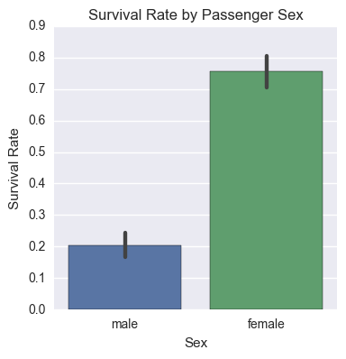

```python
# visualize the relationship between passenger sex and survival rate
g12 = sns.factorplot(x="Sex", y="Survived", data=df, kind="bar")
g12.set_axis_labels("Sex", "Survival Rate")
sns.plt.title("Survival Rate by Passenger Sex")
```

## 2. Passenger Age

### 2.1 Passenger Age as a Continuous Variable

```python
# explore the age distribution of the current sample
df["Age"].describe()
```

```
count    714.000000
mean      29.699118
std       14.526497
min        0.420000
25%       20.125000
50%       28.000000
75%       38.000000
max       80.000000
Name: Age, dtype: float64
```

```python
# identify the youngest passenger in the dataset
df[df["Age"] == 0.42]
```

|  | PassengerId | Survived | Pclass | Name | Sex | Age | SibSp | Parch | Ticket | Fare | Embarked | Age_group |
| --- | --- | --- | --- | --- | --- | --- | --- | --- | --- | --- | --- | --- |
| 803 | 804 | 1 | 3 | Thomas, Master. Assad Alexander | male | 0.42 | 0 | 1 | 2625 | 8.5167 | C | minor |

```python
# identify the oldest passenger in the dataset
df[df["Age"] == 80]
```

|  | PassengerId | Survived | Pclass | Name | Sex | Age | SibSp | Parch | Ticket | Fare | Embarked | Age_group |
| --- | --- | --- | --- | --- | --- | --- | --- | --- | --- | --- | --- | --- |
| 630 | 631 | 1 | 1 | Barkworth, Mr. Algernon Henry Wilson | male | 80.0 | 0 | 0 | 27042 | 30.0 | S | senior |

Preliminary descriptive analysis suggests that the mean age of the current sample was about 30 years old. The youngest passenger in the dataset was about 5 months old, and the oldest passenger in the sample was 80 years old, both passengers survived the incident.

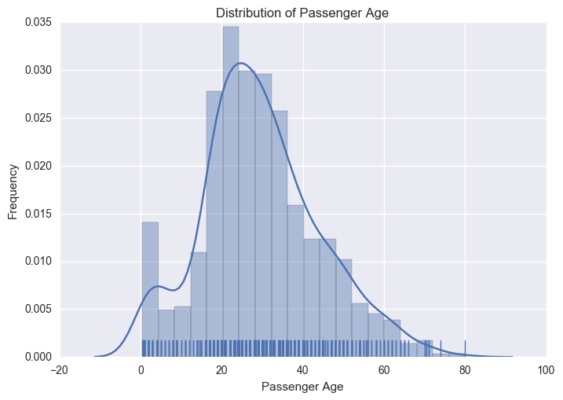

```python
# visualize the age distribution of the current sample
g21 = sns.distplot(df["Age"], kde=True, rug=True)
g21.set(xlabel="Passenger Age", ylabel="Frequency")
sns.plt.title("Distribution of Passenger Age")
```

Preliminary visual exploration suggests that the age distribution of the current sample is somewhat skewed, such that a majority of passengers were between 18 to 35 years old.

### 2.2 Passenger Age as a Categorical Variable

```python
# determine passengers who belonged to each age group
df.groupby("Age_group").size().sort_values(ascending=False)
```

```
Age_group
adult     575
minor     113
senior     26
dtype: int64
```

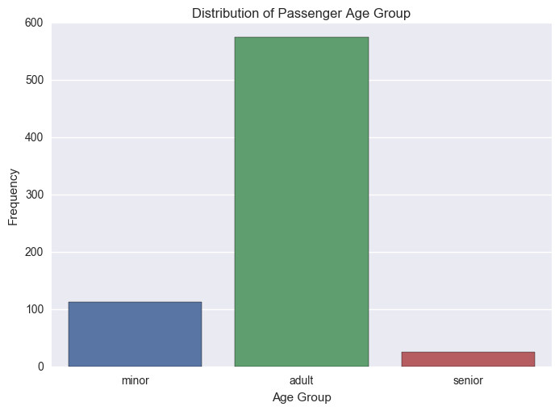

```python
# visualize passenger age group
g22 = sns.countplot(x="Age_group", data=df, order=["minor", "adult", "senior"])
g22.set(xlabel="Age Group", ylabel="Frequency")
sns.plt.title("Distribution of Passenger Age Group")
```

Descriptive and visual analysis on the categorical variable *Age_group* reveal similar age distribution pattern that is comparable to that of the continuous variable *Age*. Specifically, a majority of passengers in the sample belonged to the adult age group, with 113 passengers being under 18 years of age, and only 26 passengers being over 60 years of age.

### 2.3 Passenger Age and Survival

```python
# determine the survival rate of each age group
df.groupby("Age_group", as_index=False)["Survived"].mean().sort_values(by="Survived", ascending=False)
```

|  | Age_group | Survived |
| --- | --- | --- |
| 1 | minor | 0.539823 |
| 0 | adult | 0.386087 |
| 2 | senior | 0.269231 |

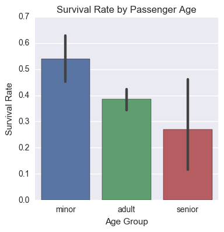

```python
# visualize the relationship between age groups and survival
g23 = sns.factorplot(x="Age_group", y="Survived", data=df, kind="bar",
               order=["minor", "adult", "senior"])
g23.set_axis_labels("Age Group", "Survival Rate")
sns.plt.title("Survival Rate by Passenger Age")
```

Descriptive and visual analysis both indicate that the survival rate for passengers under 18 years old were about 53.98%, the survival rate for adult passengers were about 38.61%, and the survival rate for passengers over 60 years old were about 26.92%. Passengers in the sample that survived seems to be younger than the passengers that did not survive. Note that there seems to be a sizeable variance on the mean survival rate of senior passengers.

## 3. Passenger Socio-economic Status (SES)

### 3.1 Passenger Socio-economic Status as a Categorical Variable

```python
# determine the size of each SES group
df.groupby("Pclass").size()
```

```
Pclass
1    186
2    173
3    355
dtype: int64
```

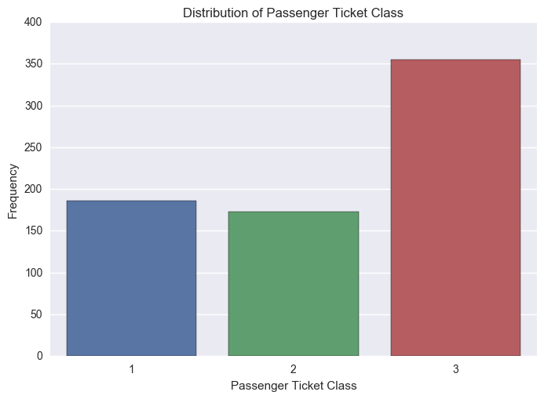

```python
# visualize passenger SES group
g31 = sns.countplot(x="Pclass", data=df)
g31.set(xlabel="Passenger Ticket Class", ylabel="Frequency")
sns.plt.title("Distribution of Passenger Ticket Class")
```

### 3.2 Passenger Socio-economic Status and Survival

```python
# determine the survival rate of each SES group
df.groupby("Pclass", as_index=False)["Survived"].mean()
```

|  | Pclass | Survived |
| --- | --- | --- |
| 0 | 1 | 0.655914 |
| 1 | 2 | 0.479769 |
| 2 | 3 | 0.239437 |

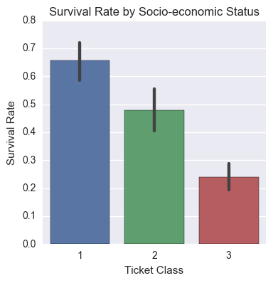

```python
# visualize relationship between SES and survival
g32 = sns.factorplot(x="Pclass", y="Survived", data=df, kind="bar")
g32.set_axis_labels("Ticket Class", "Survival Rate")
sns.plt.title("Survival Rate by Socio-economic Status")
```

Numeric and visual analysis both suggest that the survival rate for passengers in the upper class were about 65.6%, the survival rate for passengers in the middle class were about 47.98%, and the survival rate for passengers in the lower class were about 23.94%. A majority of passengers in the sample who survived seems to belong to the upper and middle social classes.

## 4. Variable Interactions

## 4.1 Interaction Between Sex and Age

```python
# determine the survival rate of each sex group controlling for age
df.groupby(["Age_group", "Sex"])["Survived"].mean()
```

```
Age_group  Sex
adult      female    0.767327
           male      0.179625
minor      female    0.690909
           male      0.396552
senior     female    1.000000
           male      0.136364
Name: Survived, dtype: float64
```

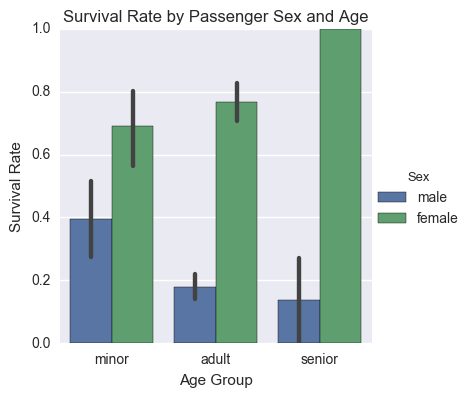

```python
# visualize interaction between sex and age
g41 = sns.factorplot(x="Age_group", hue="Sex", y="Survived", data=df, kind="bar",
               order=["minor", "adult", "senior"])
g41.set_axis_labels("Age Group", "Survival Rate")
sns.plt.title("Survival Rate by Passenger Sex and Age")
```

Numeric and visual analysis have unmasked a nontrivial interaction between the variables *Sex* and *Age_group*. Note that earlier analysis in section 2.3 suggests that survival rate of the senior age group was only about 26.92%. However, after examining each sex separately within each age group, the current investigation observes that female passengers over 60 years old in the sample achieved 100% survival rate. A general impression is that female passengers in each age group tend to have higher survival rates than their male counterparts.

## 4.2 Interaction Between Sex and Socio-economic Status

```python
# determine the survival rate of each sex group controlling for SES
df.groupby(["Pclass", "Sex"])["Survived"].mean()
```

```
Pclass  Sex
1       female    0.964706
        male      0.396040
2       female    0.918919
        male      0.151515
3       female    0.460784
        male      0.150198
Name: Survived, dtype: float64
```

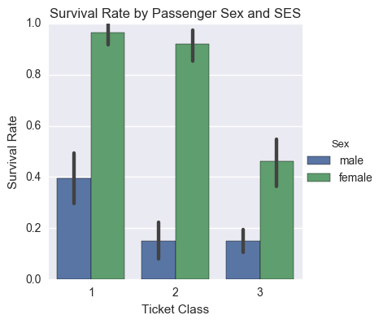

```python
# visualize interaction between sex and SES
g42 = sns.factorplot(x="Pclass", hue="Sex", y="Survived", data=df, kind="bar")
g42.set_axis_labels("Ticket Class", "Survival Rate")
sns.plt.title("Survival Rate by Passenger Sex and SES")
```

## 4.3 Interaction between Age and Socio-economic Status

```python
# determine the survival rate of each age group controlling for SES
df.groupby(["Pclass", "Age_group"])["Survived"].mean()
```

```
Pclass  Age_group
1       adult        0.675159
        minor        0.916667
        senior       0.294118
2       adult        0.417808
        minor        0.913043
        senior       0.250000
3       adult        0.202206
        minor        0.371795
        senior       0.200000
Name: Survived, dtype: float64
```

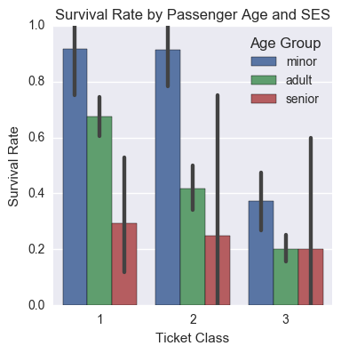

```python
# visualize interaction between age and SES
g43 = sns.factorplot(x="Pclass", hue="Age_group", y="Survived",
               data=df, kind="bar", legend=False,
               hue_order=["minor", "adult", "senior"])
g43.set_axis_labels("Ticket Class", "Survival Rate")
sns.plt.title("Survival Rate by Passenger Age and SES")
sns.plt.legend(title="Age Group")
```

Both numeric and visual exploration have uncovered a noticeable interaction between passenger age and socio-economic status. Recall from earlier analysis in section 2.3 that the survival rate of passengers under 18 years of age was around 53.98%. In comparison, the current analysis suggests that minor passengers from the upper and middle social classes achieved much higher survival rates - about 91.67% and 91.3% respectively. This pattern is not observed in the lower social class. It seems that young passengers in each SES group tend to have higher survival rates than their adult and senior counterparts, although this pattern is not as pronounced in lower social class. Note also that there seems to be a sizeable variance on the mean survival rates of senior passengers within each social class.

## 4.4 Interaction among sex, age, and socio-economic status

```python
# determine the survival rate of each sex group controlling for age and SES
df.groupby(["Pclass", "Age_group", "Sex"])["Survived"].mean()
```

```
Pclass  Age_group  Sex
1       adult      female    0.972973
                   male      0.409639
        minor      female    0.875000
                   male      1.000000
        senior     female    1.000000
                   male      0.142857
2       adult      female    0.903226
                   male      0.059524
        minor      female    1.000000
                   male      0.818182
        senior     male      0.250000
3       adult      female    0.409091
                   male      0.135922
        minor      female    0.542857
                   male      0.232558
        senior     female    1.000000
                   male      0.000000
Name: Survived, dtype: float64
```

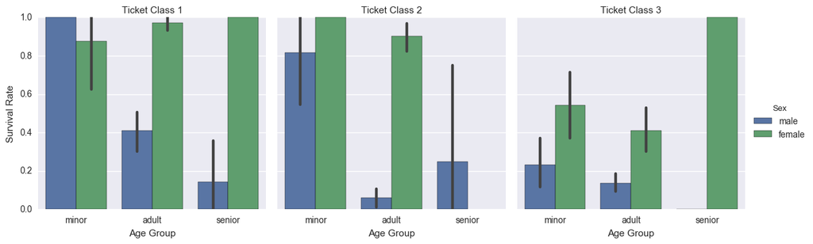

```python
# visualize interactions among sex, age, and SES
g44 = sns.factorplot(x="Age_group", hue="Sex", y="Survived", col="Pclass",
               data=df, kind="bar",
               order=["minor", "adult", "senior"])
g44.set_axis_labels("Age Group", "Survival Rate")
g44.set_titles("Ticket Class {col_name}")
```

An intricate three-way interaction among passenger sex, age and socio-economic status have been observed from both numeric and visual analysis. Across almost every age groups and social classes, female passengers obtained higher survival rates than their male counterparts. This pattern, however, does not hold true for underage passengers from the upper and middle social classes, where both female and male minor passengers obtained survival rates above 80%. Note also that there were no female passengers over 60 years old in the middle social class for the current dataset.

# Conclusion

The current investigation aims to explore key factors that are associated with the survival of the Titanic passengers. Toward this objective, the current investigation reveals that:

1. Passengers in the sample that survived seems to be mostly female.
2. Passengers in the sample that survived seems to be, in many cases, younger than the passengers that did not survive.
3. Passengers in the sample who survived seems to mostly belong to the upper and middle social classes.
4. Passengers seems to have a relatively better chance of survival if they were female, if they were under 18 years of age, and if they belonged to the upper and middle social classes.

The current investigation nonetheless suffers from a number of limitations, specifically:

1. The current investigation is unable to determine how each passenger from the sample dataset was chosen; the current sample might be subject to selection bias.
2. The current investigation suffers from a considerably reduced sample size, for having to exclude up to 177 passengers with unknown age information from data analysis.
3. The size of each age group differ drastically in the current sample; for instance, there were 575 adults and only 26 senior passengers, making it almost unsensible to directly compare the survival rates of each age group against each other.
4. The current iteration of the investigation relies almost exclusively on descriptive analysis and visual exploration; the conclusions drawn from this investigation are not yet supported by rigorous statistical procedures.

Follow-up analysis can examine the relationships and interactions among key variables, using rigorous statistical procedures such as analysis of variance (ANOVA) and multivariate analysis of variance (MANOVA), as well as submitting the dataset through machine learning algorithms.